# Convolutional Neural Networks

Jennifer Scodes and Yimo Zhang

### Overview

Convolutional neural networks (CNN) are feed-forward neural networks that specialize in processing data with a grid-like structure such as images. They can consist of convolutional layers, pooling layers, and fully connected layers but must have at least one convolutional layer. The convolutional and pooling layers compute feature extraction while the fully connected layer maps the features to the final output (i.e., classification). Within an image, the 2-dimensional space is defined by pixels to represent the visual data. The pixels can denote specific RGB color and brightness, so feature extraction begins within each pixel, and as each layer feeds into the next in a hierarchy, the features can become more complex (Yamashita et al. 2018; IBM). This eventually enables CNN to detect simple to complex patterns within the image.

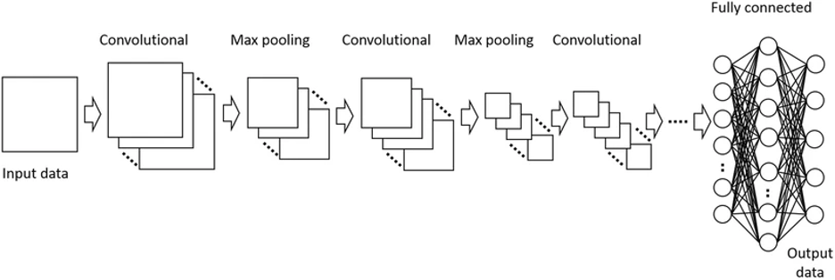

Figure 1. Overview of CNN structure (Yamashita et al., 2018)

### The Impact of CNNs

CNNs have surged in popularity given their demonstrated potential for object recognition in images (Yamashita et al., 2018). They have provided astonishing results in object recognition in competitions such as the ImageNet Large Scale Visual Recognition Challenge where the competition reached a turning point from 2012 and onward with the introduction of CNNs that started dominating all three tasks of image classification, single-object localization, and object detection (Russakovsky et al., 2015; Krizhevsky & Sutskever, 2012). The performances seen in CNNs have reached levels previously thought to only be within the human realm (Teuwen & Moriakova, 2020), and have been implemented all around us in a variety of fields such as in marketing for identifying people in photos, in healthcare for medical imaging, and even in automotive safety technology such as lane detection (IBM).

From a public health perspective, CNN has been of interest in medical research, especially radiology, for lesion detection, classification, segmentation, and image reconstruction (Yamashita et al., 2018). Its application has already been widespread and successful. For example, in a recent study aimed at evaluating the prediction performance of CNNs in diagnosing thyroid cancer from ultrasound images, Kim et al. found that CNNs had diagnostic performance comparable to experienced radiologists (AUC= 0.917 vs 0.891, respectively) (2021). In another study assessing CNNs ability to identify varying types of skin cancers in images, Esteva et al. found that CNNs achieved AUCs over 91% in identifying carcinoma and melanoma skin cancer (2017). With results like these, the effective implementation of CNN in radiological image screening can have a large and important impact in clinical practice for discovering and diagnosing disease.

### What are CNNs?

Convolutional neural networks are a specific type of neural networks that assume the inputs are structured as images. What this means is that CNNs have the same architecture as regular neural networks as in they are made up of neurons, defined as a nonlinearity applied to an affine function, with learnable weights and are trained in a similar fashion as neural networks. They consist of input layers, hidden layers, and an output layer. An example network is the following:

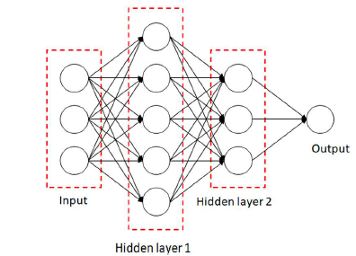

In the feedforward process, the input layer contains features, $\textbf{x}$ where $\textbf{x}$ is a $p$ x 1 matrix for $p$ input parameters that are passed through a function, $\textbf{z}^{(1)}=\sigma(\textbf{b}^{(1)} +\textbf{W}^{(1)}\textbf{x})$, with weight ($\textbf{W}$ a $m$ x $p$ matrix for m nodes in hidden layer 1), bias ($\textbf{b}$ as a m x 1 matrix), and activation function ($\sigma$) for each of the nodes in the first hidden layer (layer is indicated by $^{(1)}$ superscript). Common choices for activation functions are the sigmoid $\sigma(x)=\frac{1}{1+e^{-x}}$ and relu functions $\sigma(x)=max(0,x)$. Therefore, we can see that each node in the first hidden layer is a weighted combination of input values with an activation function applied. This process continues in a feedforward approach where the nodes in the second hidden layer will be a weighted combination of the first hidden layer ($\textbf{z}^{(2)}=\sigma(\textbf{b}^{(2)} +\textbf{W}^{(2)}\textbf{z}^{(1)}$), until we reach the output layer. The output layer contains a single node and typically a linear activation function $\sigma(x)=x$ to give an estimated value of the outcome, y, which could be a class for classification or a real value for regression.

The networks weights and bias values can then be trained to minimize the loss function relative to the outcome’s distribution. For example, for continuous outcomes the loss function is squared error: $L(y, \hat f(x))=(y-\hat f(x))^2$ and for binary outcomes the loss function is binary cross entropy: $L(y, \hat f(x))=ylog(\hat f(x))+ (1-y)log(1-\hat f(x))$. Gradient-based optimization, such as stochastic gradient descent, can be used to minimize the loss function by computing the network’s gradients through backpropagation. For more details see Teuwen & Moriakova (2020).

CNNs have the same structure as these feedforward networks (see Figure 3); however, what makes them unique is the assumption that the inputs $\textbf{x}$ are in a grid-like structure, such as in images. Because of this assumption, for imaging, the input data is stored in pixel values in a 2D grid with height, width, and depth. Then the data pass through convolution, pooling and fully connected layers as described below.

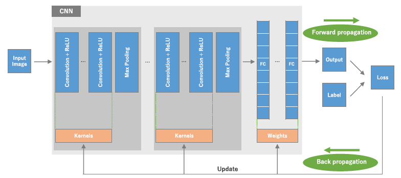

Figure 3. Overview of the typical architecture of a convolutional neural network (Yamashita et al., 2018)

#### Convolution Layer

The convolutional layer of CNN is the bread and butter of the network because it performs the feature extraction, and does so through a linear operation called convolution. In the feedforward process, a kernel filter slides across the 2-D or 3-D inputs to compute a feature map of the filter. This feature map is the sum of the element-wise product of the kernel and the input tensor (an array of numbers from sliding across the full input data, see Figure 4).

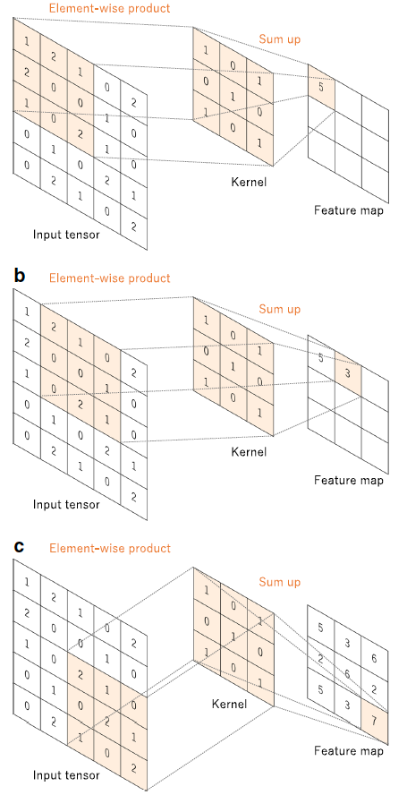

Figure 4. An example of convolution with a kernel size of 3x3 and a stride of 1 (Yamashita et al., 2018)

There are three important parameters in the convolutional layers：the size of kernel, the size of the stride, and the number of channels. Take a 2-D image as an example, the kernel is a two-dimension matrix with the number of rows and columns determined by the user. It should be smaller than the input to make the convolution operation possible. The kernel size can typically be 3x3, or larger such as 7x7. The stride refers to how many pixels the kernel window moves for each step. The stride is included as a parameter because the convolutions between two neighboring windows may be very similar and we are creating repetitive information in this sense. The number of channels refers to how many layers of 2-D data is fed into the network. For example, a colored 2D image is presented by three layers of 2-D matrix, one matrix for red, one matrix for green and one matrix for blue. In the convolutional layers, kernels moves along each of the three matrix and the result is the summation of the three convolutions. For a 2-D image, I, with three channels, ($C_1, C_2, C_3$), each channel ($C_i$) is a $m \times n$ matrix, and the kernel $K$ is a $k\times k$ matrix. Therefore, the resulting convolution at $(x,y)$ position (meaning that the first element kernel $K(1,1)$ is lined up with $(x,y)$ position of the channel matrix) is:
$$conv(I, K)_{x,y} = \sum_{i=1}^3\bigg(
\sum_{j=1}^k \sum_{l=1}^k C_i(x+j-1, y+l-1)K(j,l)\bigg)$$
The iteration on $(x,y)$ depends on the strides.

Therefore, for a $m \times n$ image with $c$ channels and $f$ kernals of size $k \times k$ and stride being $(s,s)$ the output size of the convolutional layer is:
$$dim(conv(I,K)) =
(\lfloor \frac{m+2p-k}{s}+1\rfloor, \lfloor\frac{n+2p-k}{s}+1\rfloor,
f)\;\; s>0\\
dim(conv(I,K)) = (m+2p-k, n+2p-k, f)\;\; s=0$$
where $p=0$ for valid padding and $p = \frac{k-1}{2}$ for same padding. These convolutional layer parameters need to be set prior to the training process.

#### Pooling Layer

The pooling layer is a dimension reduction layer that reduces the dimensionality of the feature maps through summary statistics. This is done to decrease the number of learnable parameters and to add invariance to small distortions in the image. Two common approaches are max pooling and average pooling. For max pooling, the maximum values are taken over patches of the input feature maps. Average pooling is similar but takes the average instead of the maximum. Common partitions are 2x2 blocks with stride 2. There are no learnable parameters in pooling layers. (Yamashita et al., 2018; Teuwen & Moriakova, 2020).

#### Fully Connected (Dense) Layer

After pooling, the feature maps are transformed into vectors (1-D arrays), and then input into the fully connected layers. These layers consist of every input connected to every output through a non-linear function with a weight and bias term. The final fully connected layer contains the activation function specific to the distribution of the output such as the sigmoid function for binary classification, the softmax function for multiclass single-class classification or the identity function for continuous values. (Yamashita et al., 2018; Teuwen & Moriakova, 2020)

#### Training CNNs

Finally, such as in the neural networks, CNNs have to be trained. For CNNs, this involves finding the convolution layer kernel and fully connected layer weights and biases that minimize the loss function. Similar to neural networks, the input data is first fed forward through the network, and the loss function, such as the difference between output predictions and true values, is computed. Then, the learnable parameters are updated through backpropogation and gradient descent. This process repeats until the loss function is minimized. A key advantage of CNNs is how the kernels are invariant for all inputs across the image. This increases model efficiency since it reduces the number of parameters needing to be learned.

Available data should be split into training, test, and validation sets in order to train the hyperparameters of the model. Doing so will allow the training set to be used to train the network, the test set to be used to measure the networks performance and for model selection, and the validation set to evaluate the performance of the final model. This process will avoid overfitting the network to the irregularities of the training data set so that the network can be generalizable to new data. Additional solutions to avoid overfitting are similar to those from neural networks, and include regularization with dropout where randomly selected activations are set to 0 (Hinton et al., 2012) or weight decay such as L2 regularization by penalizing model weights to only take small values (Yamashita et al., 2018).

### Example Application of CNN

The following example utilizes the CIFAR dataset to illustrate the use of CNN for image detection. The CIFAR dataset collected by Krizhevsky et al. is made up of 60000 $32 \times 32$ colour images in 10 classes (2009). The dataset consists of 5 batches of training set and 1 batch of test set, each with a sample size of 10000. An example of the 10 classes of images available in the CIFAR dataset are presented in Figure 5.

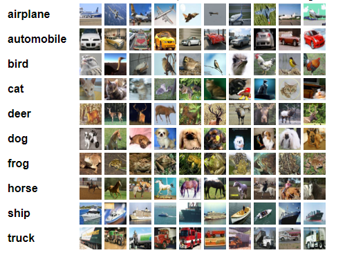

Figure 5. Examples of the 10 classes of images in CIFAR dataset. Image originally from https://www.cs.toronto.edu/~kriz/cifar.html

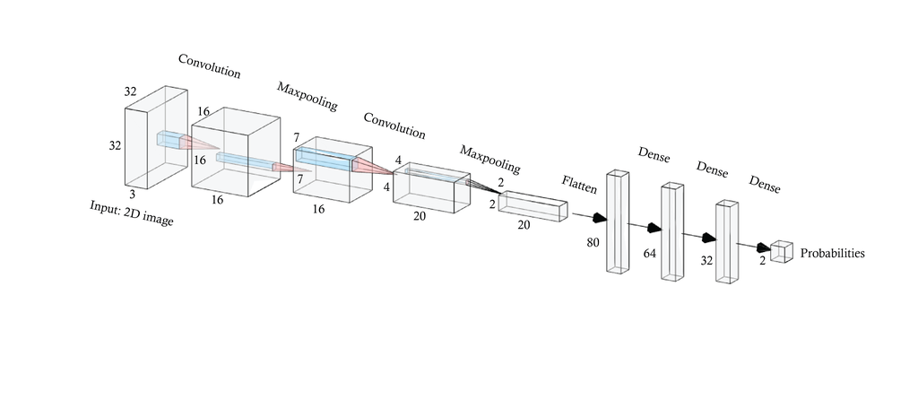

Figure 6. The setup of the CNN.

The CNN network consists of two convolutional layers, two maxpooling layers and three dense (i.e., fully connected) layers. Additionally, to avoid overfitting, two dropout layers are followed by the first two dense layers with a drop-out rate of 0.2 and all the parameters in the dense and convolutional layers are regularized by $L2$ loss with $\alpha = 0.001$. The input size is $32 \times 32$, with the third dimension referring to channels of RGB (red, green and blue). ReLU activation functions are added to each of the proceeding convolutional layer and dense layer. Softmax function is applied before the output layer in order to obtain probabilities.

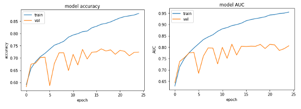

Figure 7. Accuracy and AUC of CNN models across epochs.

We see that even though both dropout and regularization is applied, there is still evidence of overfitting given the much higher values in the training set than in the test set. However, the accuracy and AUC of test set (val line in the plot) does not discourage us from believing in this model since they are still moderate in size. The accuracy of the test set stabilizes around 0.72 while the AUC of the test set stabilizes around 0.8, which is a decent result for a classification problem.

Next, we can then check out how the CNN model processes the images by plotting the output of the first convolution layer of a certain image. Below is the 10th image from the training set. We see that even though the picture is a little vague, we can see that it is a dog.

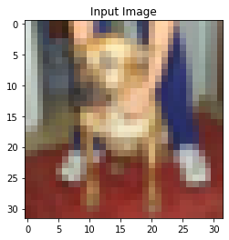

Looking below at the 16 output of the first convolutional layer, and we can see that the model tries to distinguish the outline of the object in the picture.

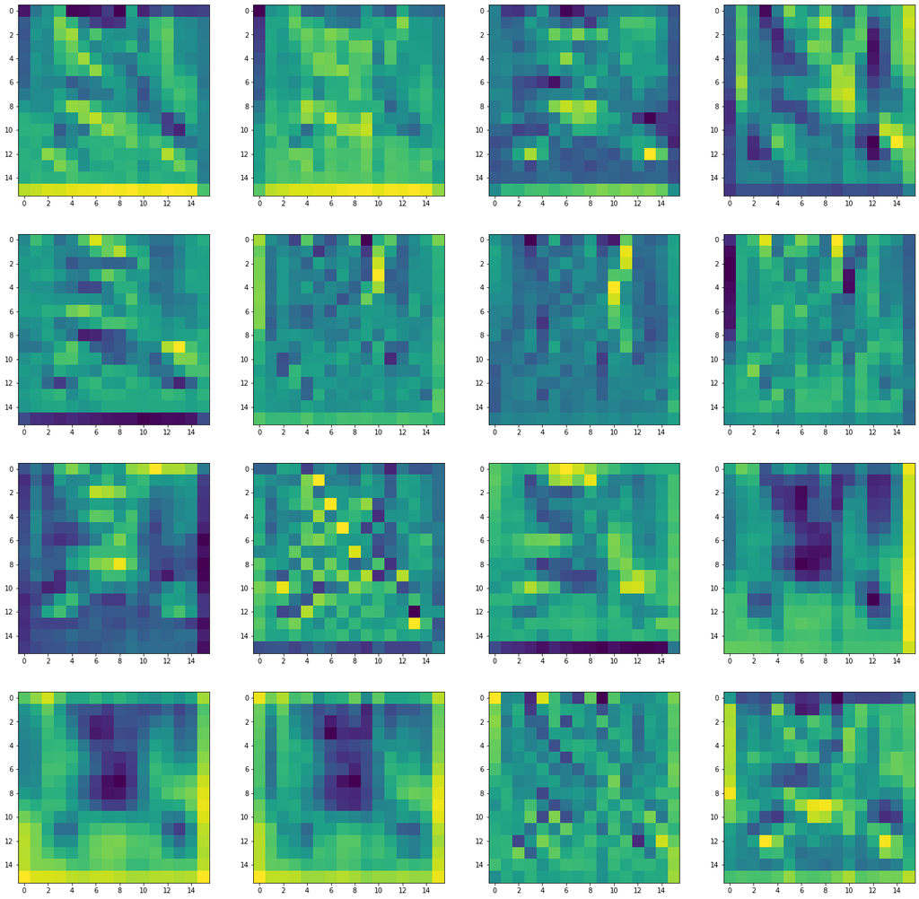

We can now look at a more developed CNN proposed by Simonyan and Zisserman in 2014 called VGG16. Their model achieves an accuracy of more than 90% on the ImageNet dataset that consists of 14 million images from 1000 classes. The CNN model structure they used is shown in Figure 8.

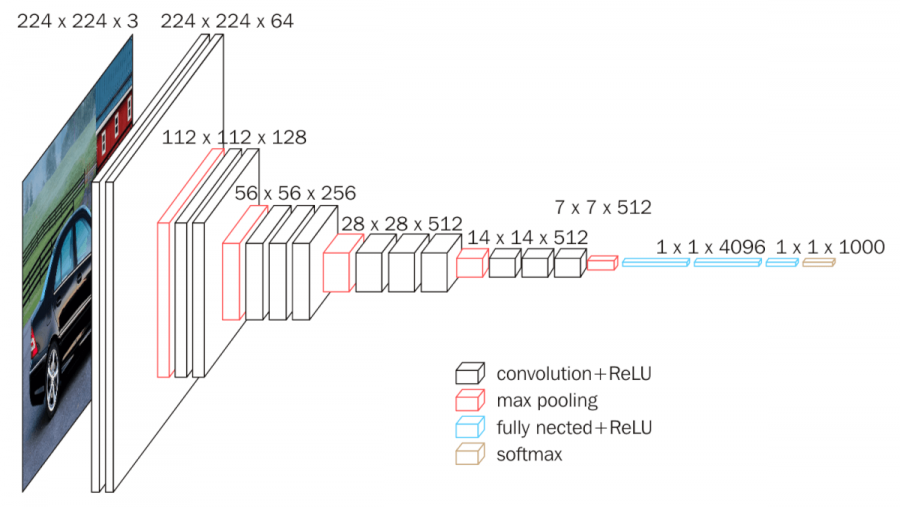

Figure 8. The structure of the VGG16 CNN by Simonyan and Zisserman (2014).

The VGG16 model has now been made available for use in keras, and the parameters are already trained based on the ImageNet dataset. Therefore, we can feed the same dog image into the VGG16 and compare the results. We see the following output from the first convolutional layer:

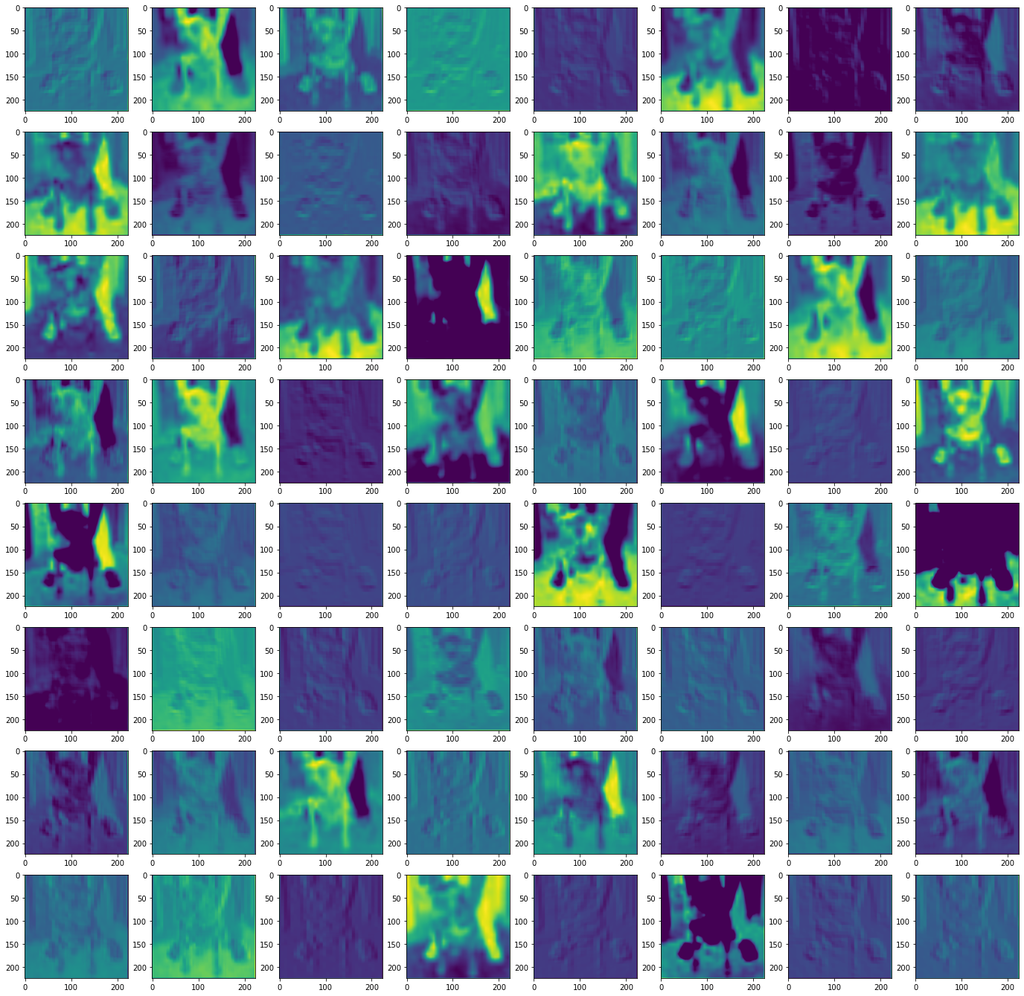

We see that the VGG16 model did a much better job in distinguishing the dog from the background as it has been trained on a dataset of millions of samples and the number of parameters in VGG16 exceeds that of our CNN model. In fact, recently people have proposed what’s called transfer learning, which aims to fine tune a well established deep learning model or part of that model on a small dataset of certain use to obtain a relatively reliable result (Pan & Yang, 2010). This can overcome the situation where there is insufficient data, for example, in medical analysis.

### References

- Convolutional Neural Networks. IBM. Retrieved April 26, 2023, from https://www.ibm.com/topics/convolutional-neural-networks
- Esteva, A., Kuprel, B., Novoa, R. et al. (2017). Dermatologist-level classification of skin cancer with deep neural networks. Nature 542, 115–118. https://doi.org/10.1038/nature21056
- Hinton, G.E., Srivastava, N., Krizhevsky, A. et al. (2012). Improving neural networks by preventing co-adaptation of feature detectors. arXiv.Available online at: https://arxiv.org/pdf/1207.0580.pdf. Accessed 11 May 2023
- Krizhevsky, A. (2009). Learning multiple layers of features from tiny images. Technical Report TR-2009, University of Toronto, Toronto.
- Krizhevsky, A., Sutskever, I., Hinton, G.E. (2012). ImageNet classification with deep convolutional neural networks. Adv Neural Inf Process Syst 25. Available online at: https://papers.nips.cc/paper/4824-imagenet-classification-with-deep-convolutional-neural-networks.pdf. Accessed 26 Apr 2023
- Pan, S.J. & Yang, Q. (2010). A Survey on Transfer Learning. IEEE Transactions on Knowledge and Data Engineering 22:10, 1345-1359. https://doi.org/10.1109/TKDE.2009.191
- Russakovsky, O., Deng, J., Su, H. et al. (2015). ImageNet Large Scale Visual Recognition Challenge. Int J Comput Vis 115, 211–252. https://doi.org/10.1007/s11263-015-0816-y
- Simonyan, K. & Zisserman, A. (2014). Very deep convolutional networks for large-scale image recognition. arXiv preprint arXiv:1409.1556.
- Teuwen, J. & Moriakova, N. (2020) Handbook of Medical Image Computing and Computer Assisted Intervention. Chapter 20: Convolutional neural networks. https://doi.org/10.1016/B978-0-12-816176-0.00025-9
- Yamashita, R., Nishio, M., Do, R.K.G. et al. (2018). Convolutional neural networks: an overview and application in radiology. Insights Imaging 9, 611–629. https://doi.org/10.1007/s13244-018-0639-9